# PYTHON PROGRAMMING

## I. Python Hello World

```python
from IPython.display import display
print("Hello World")
```

```
Hello World
```

## II. Python Syntax

### 1. comment

```python
print("Hello World") # This is comment not show when run
```

```
Hello World
```

### 2. Indentation

```python
score = 80
if score >=60:
    print("Pass")
```

```
Pass
```

### 3. Variables

```python
x = 2
price = 2.5
print(type(price))
word = 'Hello'
print(type(word))
word = 'Hello'
word = "Hello"
word = '''Hello'''
print(type(word))
```

```
<class 'float'>
<class 'str'>
<class 'str'>
```

```python
x = 2
display(x)
display(type(x))
y = x + 1
display(y)
display(type(y))
```

```
2
```

```
int
```

```
3
```

```
int
```

### 4. Version

```python
from platform import python_version
print("Python Version:", python_version()) # show python version
```

```
Python Version: 3.13.1
```

### 5. Data Types

```python
x = "Hello World"
print(type(x))
x = 2 #int
print(type(x))
x = 2.5 #float
print(type(x))
x = 7j #complex
print(type(x))
```

```
<class 'str'>
<class 'int'>
<class 'float'>
<class 'complex'>
```

```python
x = ["apple", "banana", "cherry"] #list
print(type(x))
x = ("apple", "banana", "cherry") #tuple khong co the thay doi
print(type(x))
x = range(6) #range
print(type(x))
x = {"name" : "Tom", "age" : 20} #dict
print(type(x))
x = {"apple", "banana", "cherry"} #set
print(type(x))
x = frozenset({"apple", "banana", "cherry"})
print(type(x))
```

```
<class 'list'>
<class 'tuple'>
<class 'range'>
<class 'dict'>
<class 'set'>
<class 'frozenset'>
```

```python
x = True #bool
print(type(x))
x = b"Hello" #bytes
print(type(x))
x = bytearray(5) #bytearray
print(type(x))
x = memoryview(bytes(5)) #memoryview
print(type(x))
x = None #NoneType
print(type(x))
```

```
<class 'bool'>
<class 'bytes'>
<class 'bytearray'>
<class 'memoryview'>
<class 'NoneType'>
```

### 6. Casting

```python
x = str(3) # x will be '3'
display(x)
y = int(3) # y will be 3
display(y)
z = float(3) # z will be 3.0
display(z)
print(x, type(x))
print(y, type(y))
print(z, type(z))
```

```
'3'
```

```
3
```

```
3.0
```

```
3 <class 'str'>
3 <class 'int'>
3.0 <class 'float'>
```

### 7. Numbers

```python
x = 2 # int
display(x)
y = 3.4 # float
display(y)
z = 7j #complex
display(z)
print(x, type(x))
print(y, type(y))
print(z, type(z))
```

```
2
```

```
3.4
```

```
7j
```

```
2 <class 'int'>
3.4 <class 'float'>
7j <class 'complex'>
```

### 8. Arithmetic Operators And Basic Operators

```python
# addition
print(5 + 2)
# subtraction
print(5 - 2)
# multiplication
print(5 * 2)
# division
print(5 / 2)
# floor division
print(5 // 2)
# modulus
print(5 % 2)
# exponentiation
print(5 ** 2)   # 5^2
```

```
7
3
10
2.5
2
1
25
```

```python
print('7 + 2 =', 7 + 2)
print('7 - 2 =', 7 - 2)
print('7 * 2 =', 7 * 2)
print('7 / 2 =', 7 / 2)
print('7 // 2 =', 7 // 2)
print('7 % 2 =', 7 % 2)
print('7 ** 2 =', 7 ** 2)
```

```
7 + 2 = 9
7 - 2 = 5
7 * 2 = 14
7 / 2 = 3.5
7 // 2 = 3
7 % 2 = 1
7 ** 2 = 49
```

```python
### 8. True or False
```

```python
print(3 > 2)
print(3 == 2)
print(3 < 2)
```

```
True
False
False
```

- BMI Calculator

```python
height_cm = 170
weight_kg = 77
height_m = height_cm/100
BMI = (weight_kg/(height_m**2))

print("Your BMI is: " + str(round(BMI,1)))
```

```
Your BMI is: 26.6
```

How much is your $100 worth after 7 years?

```python
fv = 100 * 1.1 ** 7 # 1.1 lai suat nam (10%)
print('fv = ', round(fv, 2))
```

```
fv =  194.87
```

Future Value

```python
pv = 100 #pv = present value
r = 0.1 # r = interest rate
n = 7 # n = number of years
fv = pv * ((1 + (r)) ** n)
print(round(fv, 2))
```

```
194.87
```

```python
amount = 100 # pv
interest = 10 #r
years = 7 #n

future_value = amount * ((1 + (0.01 * interest)) ** years)
print(round(future_value, 2))
```

```
194.87
```

### 9. Collections

#### 9.1. Lists []

- List []: Có thứ tự và thay đổi được, cho phép trùng lặp. Dùng khi cần danh sách có vị trí/index, thêm–xóa–sửa tự do.

```python
x = [60, 70, 80, 90]
print(len(x))
print(x[0])
print(x[1])
print(x[-1])
```

```
4
60
70
90
```

#### 9.2. Tuple ()

- Tuple (): có thứ tự, không thay đổi (immutable), cho phép trùng phần tử. Dùng cho gói dữ liệu “bất biến” (tọa độ, record cố định), dùng làm key trong dict nếu toàn bộ phần tử hashable.

```python
x = (10, 20, 30, 40, 50)
print(x[0])
print(x[1])
print(x[2])
print(x[-1])
```

```
10
20
30
50
```

#### 9.2. Sets {}

- Là tập hợp các phần tử không trùng lặp, không có thứ tự. Dùng khi cần lưu trữ các giá trị duy nhất và các phép toán tập hợp (union, intersection…).

**Lưu ý:** {} là dict rỗng, set rỗng phải tạo bằng set().

```python
animals = {'cat', 'dog'}
print('cat' in animals)
print('fish' in animals)
animals.add('fish') # animals = {'cat', 'dog', 'fish'}
print('fish' in animals)
print(len(animals))
animals.add('cat')
print(len(animals))
animals.remove('cat')
print(len(animals))
```

```
True
False
True
3
3
2
```

#### 9.3. Dictionary {key : value}

- Là tập hợp các cặp key:value, không có thứ tự, thay đổi được, không cho phép trùng key. Dùng khi cần lưu trữ dữ liệu theo cặp key:value, truy xuất nhanh theo key.

```python
k = { 'EN':'English', 'FR':'French' }
print(k['EN'])
```

```
English
```

Python for Finance Applications

```python
# Python Lists
expenses = [72.50, 80.75, 50.00, 90.25]
total_expenses = sum(expenses)
print("Total expenses:", total_expenses)
```

```
Total expenses: 293.5
```

```python
# Python Tuples
accounts = (("Cash", 1001), ("Accounts Receivable", 1002), ("Inventory", 1003))
for account in accounts:
    print("Account name:", account[0], "Account number:", account[1])
```

```
Account name: Cash Account number: 1001
Account name: Accounts Receivable Account number: 1002
Account name: Inventory Account number: 1003
```

```python
# Python Sets
account_numbers = {1001, 1002, 1003}
new_account_number = 1004
if new_account_number not in account_numbers:
    print("Account number", new_account_number, "is not in use.")
```

```
Account number 1004 is not in use.
```

```python
# Python Dictionaries
accounts = {"1001": {"name": "Cash", "balance": 500.00, "type": "Asset"},
            "1002": {"name": "Accounts Receivable", "balance": 1000.00, "type": "Asset"},
            "2001": {"name": "Accounts Payable", "balance": 750.00, "type": "Liability"}}
for account_number, account_info in accounts.items():
    print("Account number:", account_number)
    print("Account name:", account_info["name"])
    print("Account balance:", account_info["balance"])
    print("Account type:", account_info["type"])
```

```
Account number: 1001
Account name: Cash
Account balance: 500.0
Account type: Asset
Account number: 1002
Account name: Accounts Receivable
Account balance: 1000.0
Account type: Asset
Account number: 2001
Account name: Accounts Payable
Account balance: 750.0
Account type: Liability
```

### 10. Control Logic and Loops

#### 10.1. If, if else, if elif else

```python
# Python if
score = 80
if score >=60 :
    print("Pass")
```

```
Pass
```

```python
# Python if else
score = 80
if score >=60 :
    print("Pass")
else:
    print("Fail")
```

```
Pass
```

```python
score = 95
if score >= 90 :
    print("A")
elif score >=60 :
    print("Pass")
else:
    print("Fail")
```

```
A
```

```python
# Python if elif else
score = 90
grade = ""
if score >=90:
    grade = "A"
elif score >= 80:
    grade = "B"
elif score >= 70:
    grade = "C"
elif score >= 60:
    grade = "D"
else:
    grade = "E"
print(grade)
```

```
A
```

#### 10.2. Loops

##### 10.2.1 for loops

```python
for i in range(1,6):
    print(i)
```

```
1
2
3
4
5
```

```python
# for loops
for i in range(1,10):
    for j in range(1,10):
        print(i, ' * ' , j , ' = ', i*j)
```

```
1  *  1  =  1
1  *  2  =  2
1  *  3  =  3
1  *  4  =  4
1  *  5  =  5
1  *  6  =  6
1  *  7  =  7
1  *  8  =  8
1  *  9  =  9
2  *  1  =  2
2  *  2  =  4
2  *  3  =  6
2  *  4  =  8
2  *  5  =  10
2  *  6  =  12
```

[output cut: 66 more lines]

##### 10.2.2 while loops

```python
# while loops
age = 10
while age < 20:
    print(age)
    age = age + 1
```

```
10
11
12
13
14
15
16
17
18
19
```

### 11. Function def

```python
# Python Function def
# indentation for blocks. four spaces
def getfv(pv, r, n):
    fv = pv * ((1 + (r)) ** n)
    return fv
fv = getfv(100, 0.1, 7)
print(round(fv, 2))
```

```
194.87
```

### 11. Classes/Objects

```python
# Python class
class MyClass:
    x = 5
c1 = MyClass()
print(c1.x)
```

```
5
```

```python
class Person:

    def __init__(self, name, age):
        self.name = name
        self.age = age

p1 = Person("Alan", 20)
print(p1.name)
print(p1.age)
```

```
Alan
20
```

```python
class Person:

    def __init__(self, name, age):
        self.name = name
        self.age = age

    def myfunc(self):
        print("Hello my name is " + self.name)

p1 = Person("Alan", 20)
p1.myfunc()
```

```
Hello my name is Alan
```

```python
class Person:

    def __init__(self, name, age):
        self.name = name
        self.age = age

    def myfunc(self):
        print("Hello my name is " + self.name)

p1 = Person("Alan", 20)
p1.myfunc()
print(p1.name)
print(p1.age)
```

```
Hello my name is Alan
Alan
20
```

```python
class Vehicle:
    name = ""
    kind = "car"
    color = ""
    value = 100.00
    def description(self):
        desc_str = "%s is a %s %s worth $%.2f." % (self.name, self.color, self.kind, self.value)
        return desc_str
```

```python
car1 = Vehicle()
car1.name = "Fer"
car1.color = "red"
car1.kind = "convertible"
car1.value = 60000.00

car2 = Vehicle()
car2.name = "Jump"
car2.color = "blue"
car2.kind = "van"
car2.value = 10000.00

print(car1.description())
print(car1.name)
print(car2.description())
print(car2.name)
```

```
Fer is a red convertible worth $60000.00.
Fer
Jump is a blue van worth $10000.00.
Jump
```

### 12. Modules

- Là một file .py chứa hàm/biến/lớp để tái sử dụng

```python
import mymodule
print("Loaded from:", mymodule.__file__) # Kiểm tra file đã load
mymodule.greeting("Alan")
```

```
Loaded from: d:\LTT_DA\Day2_Python_programming\mymodule.py
Hello, Alan
```

```python
# Python File Input / Output
with open('myfile.txt', 'w') as file:
    file.write('Hello World\nThis is Python File Input Output')

with open('myfile.txt', 'r') as file:
    text = file.read()
    print(text)
```

```
Hello World
This is Python File Input Output
```

```python
# Python File Input / Output
filename = 'mymodule.py'
with open(filename, 'w') as file:
    text = '''def greeting(name):
    print("Hello, " + name)
    '''
    file.write(text)

with open(filename, 'r') as file:
    text = file.read()

print(filename)
print(text)
```

```
mymodule.py
def greeting(name):
    print("Hello, " + name)
```

```python
# mymodule.py
def greeting(name):
    print("Hello, " + name)

mymodule.greeting("Alan")
```

```
Hello, Alan
```

```python
#Python main() function
def main():
    print("Hello World!")

if __name__ == "__main__":
    main()
```

```
Hello World!
```

### 13. Files and Exception Handling

```python
f = open("myfile.txt", "w")

f.write("Hello World")
f.close()

f = open("myfile.txt", "r")

text = f.read()
print(text)
f.close()
```

```
Hello World
```

```python
# Python File Input / Output
with open('myfile.txt', 'w') as file:
    file.write('Hello World')

with open('myfile.txt', 'r') as file:
    text = file.read()

print(text)
```

```
Hello World
```

```python
# Python File Input / Output
with open('myfile.txt', 'w') as file:
    file.write('Hello World\nPython File IO')

with open('myfile.txt', 'r') as file:
    text = file.read()

print(text)
```

```
Hello World
Python File IO
```

```python
# Python File Input / Output
with open('myfile.txt', 'a+') as file:

    file.write('\n' + 'New line')

with open('myfile.txt', 'r') as file:

    text = file.read()

print(text)
```

```
Hello World
Python File IO
New line
```

### 14. OS, IO, files, and Google Drive

```python
import os

cwd = os.getcwd()
print(cwd)
```

```
d:\LTT_DA\Day2_Python_programming
```

```python
os.listdir(cwd)
```

```
['day2_numpy_python101.ipynb',
 'day2_python101.ipynb',
 'myfile.txt',
 'mymodule.py',
 '__pycache__']
```

```python
path = os.path.join(cwd,'sample_data')
print(path)
```

```
d:\LTT_DA\Day2_Python_programming\sample_data
```

```python
from IPython.display import FileLink
import os, time

fname = "io_file_myday.txt"
with open(fname, "w", encoding="utf-8") as f:
    f.write("Google Colab File Write Text some content Myday")

time.sleep(1)

display(FileLink(fname))
print("Saved at:", os.path.abspath(fname))
```

io_file_myday.txt

```
Saved at: d:\LTT_DA\Day2_Python_programming\io_file_myday.txt
```

```python
import os
if os.path.exists("myfile.txt"):
    os.remove("myfile.txt")
    print("myfile.txt removed")
else:
    print("The file does not exist")
```

```
myfile.txt removed
```

```python
import os
os.listdir()
os.mkdir("myfolder1")
os.listdir()
os.rmdir("myfolder1")
os.listdir()
```

```
['day2_numpy_python101.ipynb',
 'day2_python101.ipynb',
 'io_file_myday.txt',
 'mymodule.py',
 '__pycache__']
```

### 15. Try Except

```python
#Python try except
try:
    print(x)
except:
    print("Exception Error")
```

```
(10, 20, 30, 40, 50)
```

```python
#Python try except finally
try:
    print("Hello")
except:
    print("Exception Error")
finally:
    print("Finally process")
```

```
Hello
Finally process
```

```python
try:
    print("Hello")
except:
    print("Exception Error")
else:
    print("No exception")
finally:
    print("Finally process")
```

```
Hello
No exception
Finally process
```

```python
try:
    price = float(input("Enter the price of the stock (e.g. 10):"))
    shares = int(input("Enter the number of shares (e.g. 2):"))
    total = price * shares
except Exception as e:
    print("Exception error:", str(e))
else:
    print("The total value of the shares is:", total)
finally:
    print("Thank you.")
```

```
The total value of the shares is: 20.0
Thank you.
```

```python
try:
    file = open("myfile.txt")
    file.write("Python write file")
    print("file saved")
except:
    print("Exception file Error")
```

```
Exception file Error
```

```python
try:
    file = open("myfile.txt")
    file.write("Python write file")
    print("file saved")
except:
    print("Exception file Error")
finally:
    file.close()
    print("Finally process")
```

```
Exception file Error
Finally process
```

```python
try:
    file = open("myfile.txt", 'w')
    file.write("Python write file")
    print("file saved")
except:
    print("Exception file Error")
finally:
    file.close()
    print("Finally process")
```

```
file saved
Finally process
```

## III. NumPy

```python
v = list(range(1, 6))
print(v)

v2 = 2 * v
print(v2)

import numpy as np
v = np.arange(1, 6)
v2 = 2 * v
print(v)
print(v2)
```

```
[1, 2, 3, 4, 5]
[1, 2, 3, 4, 5, 1, 2, 3, 4, 5]
[1 2 3 4 5]
[ 2  4  6  8 10]
```

```python
import numpy as np
a = np.array([1, 2, 3])
b = np.array([4, 5, 6])
c = a * b
c
```

```
array([ 4, 10, 18])
```

```python
import numpy as np
a = np.arange(15).reshape(3, 5)
print(a)
print(a.shape)
a.ndim
a.dtype.name # data type
```

```
[[ 0  1  2  3  4]
 [ 5  6  7  8  9]
 [10 11 12 13 14]]
(3, 5)
```

```
'int64'
```

### 1. One-dimensional Array (1-D Array)

```python
from IPython.display import display
import numpy as np
a = np.array([1,2,3,4,5])
display(a)
```

```
array([1, 2, 3, 4, 5])
```

### 2. Two-dimensional Array (2-D Array)

```python
a = np.array([[1,2,3,4,5],[6,7,8,9,10],[11,12,13,14,15],[16,17,18,19,20]])
display(a)
```

```
array([[ 1,  2,  3,  4,  5],
       [ 6,  7,  8,  9, 10],
       [11, 12, 13, 14, 15],
       [16, 17, 18, 19, 20]])
```

```python
import numpy as np
a = np.array([[0, 1, 2, 3],
[10, 11, 12, 13],
[20, 21, 22, 23]])
display(a)
```

```
array([[ 0,  1,  2,  3],
       [10, 11, 12, 13],
       [20, 21, 22, 23]])
```

```python
a = np.array([[0, 1, 2, 3], [10, 11, 12, 13], [20, 21, 22, 23]])
print(a)
print("---------------------")
print(a.ndim)
print("---------------------")
print(a.shape)
```

```
[[ 0  1  2  3]
 [10 11 12 13]
 [20 21 22 23]]
---------------------
2
---------------------
(3, 4)
```

Phân biệt Scalar/Vector/Matrix/Tensor

```python
a = 80
print("Scalar", a, type(a))
print("---------------------")
a = [50, 60, 70]
print("Vector", a, type(a))
print("---------------------")
a = np.array([[50, 60, 70], [10, 20, 30], [14, 15, 16]])
print("Matrix", a, type(a))
```

```
Scalar 80 <class 'int'>
---------------------
Vector [50, 60, 70] <class 'list'>
---------------------
Matrix [[50 60 70]
 [10 20 30]
 [14 15 16]] <class 'numpy.ndarray'>
```

## IV. Pandas

### 1. Series (1-dimensional)

```python
import pandas as pd
s = pd.Series([1,3,5,np.nan,6,8])
s
```

```
0    1.0
1    3.0
2    5.0
3    NaN
4    6.0
5    8.0
dtype: float64
```

### 2. DataFrame (2-dimensional)

```python
df = pd.DataFrame({"a": [4, 5, 6],
"b": [7, 8, 9],
"c": [10, 11, 12]},
index = [1, 2, 3])
print(df)
type(df)
```

```
   a  b   c
1  4  7  10
2  5  8  11
3  6  9  12
```

```
pandas.core.frame.DataFrame
```

```python
dates = pd.date_range('20181001', periods=6)
dates
```

```
DatetimeIndex(['2018-10-01', '2018-10-02', '2018-10-03', '2018-10-04',
               '2018-10-05', '2018-10-06'],
              dtype='datetime64[ns]', freq='D')
```

```python
df = pd.DataFrame(np.random.randn(6,4),
index=dates, columns=list('ABCD'))
df
```

|  | A | B | C | D |
| --- | --- | --- | --- | --- |
| 2018-10-01 | 2.811763 | 2.333715 | 0.840324 | -0.371646 |
| 2018-10-02 | 0.687629 | -0.062236 | 0.201818 | -0.039813 |
| 2018-10-03 | -1.005098 | 0.349838 | -1.463623 | -0.537816 |
| 2018-10-04 | 0.379557 | -0.315306 | -1.871567 | 0.687871 |
| 2018-10-05 | -0.559892 | -0.540040 | 1.767788 | 1.322712 |
| 2018-10-06 | 1.367568 | 1.048925 | 0.611376 | -0.295372 |

```python
df = pd.DataFrame(np.random.randn(3,5),
index=['student1','student2','student3']
, columns=list('ABCDE'))
df
```

|  | A | B | C | D | E |
| --- | --- | --- | --- | --- | --- |
| student1 | -0.596974 | 1.153019 | -0.081494 | -0.475007 | 0.190045 |
| student2 | -0.782579 | 0.318754 | 0.281728 | 0.004614 | 0.913252 |
| student3 | 0.612640 | 0.547045 | -0.035161 | 1.136277 | 0.890487 |

```python
df2 = pd.DataFrame({ 'A' : 1.,
'B' : pd.Timestamp('20181001'),
'C' : pd.Series(2.5,index=list(range(4)),dtype='float32'),
'D' : np.array([3] * 4,dtype='int32'),
'E' : pd.Categorical(["test","train","test","train"]),
'F' : 'foo' })
df2
```

|  | A | B | C | D | E | F |
| --- | --- | --- | --- | --- | --- | --- |
| 0 | 1.0 | 2018-10-01 | 2.5 | 3 | test | foo |
| 1 | 1.0 | 2018-10-01 | 2.5 | 3 | train | foo |
| 2 | 1.0 | 2018-10-01 | 2.5 | 3 | test | foo |
| 3 | 1.0 | 2018-10-01 | 2.5 | 3 | train | foo |

```python
df2.dtypes
```

```
A          float64
B    datetime64[s]
C          float32
D            int32
E         category
F           object
dtype: object
```

Python Finance Application with Pandas

```python
import pandas as pd
# Create a DataFrame to store transactions
columns = ['Date', 'Description', 'Amount']
ledger = pd.DataFrame(columns=columns)
# Function to add a transaction
def add_transaction(date, description, amount):
    global ledger
    new_transaction = pd.DataFrame([[date, description, amount]], columns=columns)
    ledger = pd.concat([ledger, new_transaction], ignore_index=True)
# Function to view the ledger
def view_ledger():
    print(ledger)
# Function to get the current balance
def get_balance():
    return ledger['Amount'].sum()
# Adding sample transactions
add_transaction('2023-11-01', 'Income', 1000)
add_transaction('2023-11-02', 'Groceries', -200)
add_transaction('2023-11-03', 'Utilities', -100)
# Viewing the ledger
view_ledger()
# Checking the current balance
print("Current Balance:", get_balance())
```

```
         Date Description Amount
0  2023-11-01      Income   1000
1  2023-11-02   Groceries   -200
2  2023-11-03   Utilities   -100
Current Balance: 700
```

## V. Visualization

### 1. Iris

!{sys.executable} -m pip install -U seaborn matplotlib pandas|

!{sys.executable} -m pip install -U seaborn

#### 1.1. Import

```python
import numpy as np
import pandas as pd
import matplotlib.pyplot as plt
import seaborn as sns
from pandas.plotting import scatter_matrix
```

#### 1.2. Get data and show info

```python
url = "https://archive.ics.uci.edu/ml/machine-learning-databases/iris/iris.data"
names = ['sepal-length', 'sepal-width', 'petal-length', 'petal-width', 'class']
df = pd.read_csv(url, names=names)
print(df.head(10))
```

```
   sepal-length  sepal-width  petal-length  petal-width        class
0           5.1          3.5           1.4          0.2  Iris-setosa
1           4.9          3.0           1.4          0.2  Iris-setosa
2           4.7          3.2           1.3          0.2  Iris-setosa
3           4.6          3.1           1.5          0.2  Iris-setosa
4           5.0          3.6           1.4          0.2  Iris-setosa
5           5.4          3.9           1.7          0.4  Iris-setosa
6           4.6          3.4           1.4          0.3  Iris-setosa
7           5.0          3.4           1.5          0.2  Iris-setosa
8           4.4          2.9           1.4          0.2  Iris-setosa
9           4.9          3.1           1.5          0.1  Iris-setosa
```

```python
df.tail(10)
```

|  | sepal-length | sepal-width | petal-length | petal-width | class |
| --- | --- | --- | --- | --- | --- |
| 140 | 6.7 | 3.1 | 5.6 | 2.4 | Iris-virginica |
| 141 | 6.9 | 3.1 | 5.1 | 2.3 | Iris-virginica |
| 142 | 5.8 | 2.7 | 5.1 | 1.9 | Iris-virginica |
| 143 | 6.8 | 3.2 | 5.9 | 2.3 | Iris-virginica |
| 144 | 6.7 | 3.3 | 5.7 | 2.5 | Iris-virginica |
| 145 | 6.7 | 3.0 | 5.2 | 2.3 | Iris-virginica |
| 146 | 6.3 | 2.5 | 5.0 | 1.9 | Iris-virginica |
| 147 | 6.5 | 3.0 | 5.2 | 2.0 | Iris-virginica |
| 148 | 6.2 | 3.4 | 5.4 | 2.3 | Iris-virginica |
| 149 | 5.9 | 3.0 | 5.1 | 1.8 | Iris-virginica |

```python
df.describe()
```

|  | sepal-length | sepal-width | petal-length | petal-width |
| --- | --- | --- | --- | --- |
| count | 150.000000 | 150.000000 | 150.000000 | 150.000000 |
| mean | 5.843333 | 3.054000 | 3.758667 | 1.198667 |
| std | 0.828066 | 0.433594 | 1.764420 | 0.763161 |
| min | 4.300000 | 2.000000 | 1.000000 | 0.100000 |
| 25% | 5.100000 | 2.800000 | 1.600000 | 0.300000 |
| 50% | 5.800000 | 3.000000 | 4.350000 | 1.300000 |
| 75% | 6.400000 | 3.300000 | 5.100000 | 1.800000 |
| max | 7.900000 | 4.400000 | 6.900000 | 2.500000 |

```python
print(df.info())
print(df.shape)
```

```
<class 'pandas.core.frame.DataFrame'>
RangeIndex: 150 entries, 0 to 149
Data columns (total 5 columns):
 #   Column        Non-Null Count  Dtype
---  ------        --------------  -----
 0   sepal-length  150 non-null    float64
 1   sepal-width   150 non-null    float64
 2   petal-length  150 non-null    float64
 3   petal-width   150 non-null    float64
 4   class         150 non-null    object
dtypes: float64(4), object(1)
memory usage: 6.0+ KB
None
(150, 5)
```

```python
df.groupby('class').size() # Check missing data
```

```
class
Iris-setosa        50
Iris-versicolor    50
Iris-virginica     50
dtype: int64
```

#### 1.3. Check Outlier

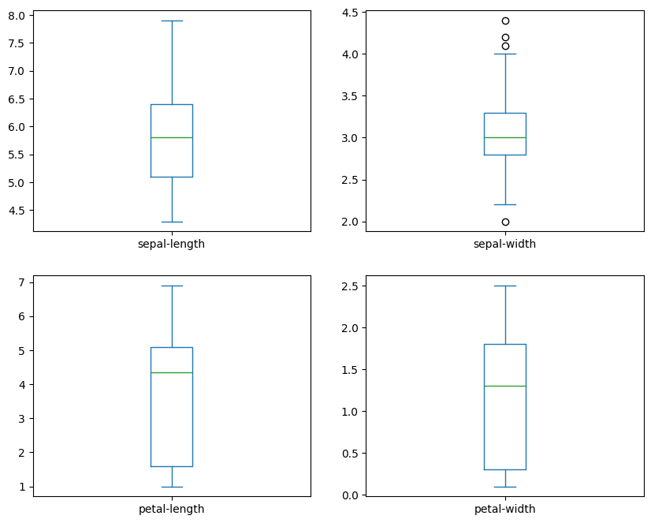

```python
plt.rcParams["figure.figsize"] = (10,8)
df.plot(kind='box', subplots=True, layout=(2,2), sharex=False, sharey=False)
plt.show()
```

#### 1.4. Chart historigram

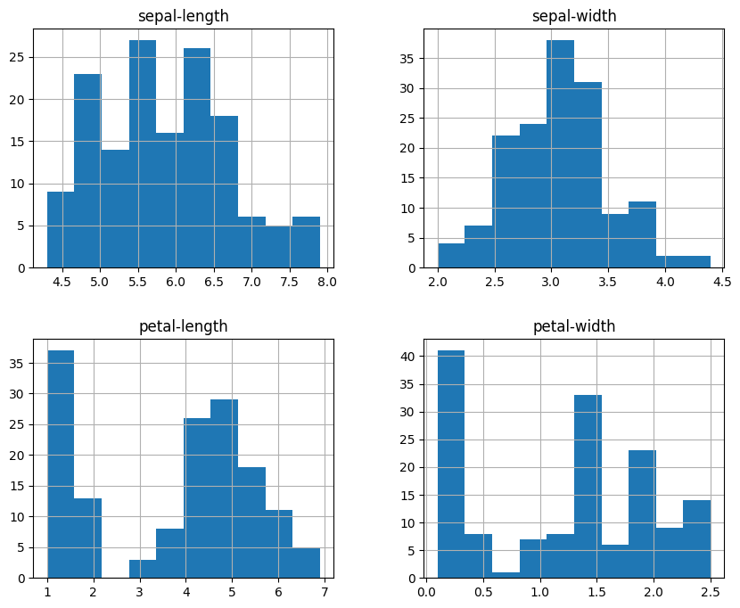

```python
df.hist()
plt.show()
```

#### 1.5. Chart Matrix

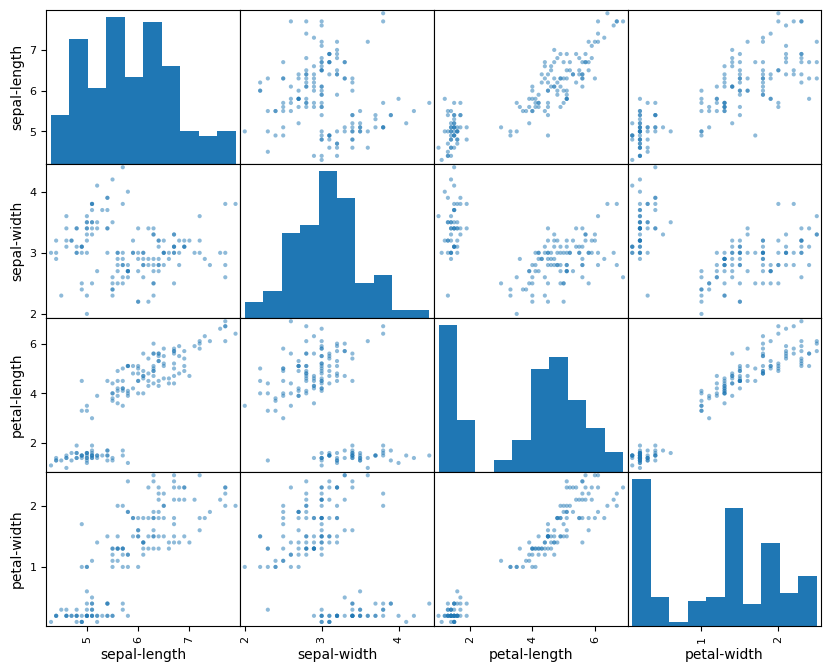

```python
scatter_matrix(df)

plt.show()
```

#### 1.6. Chart Seaborn

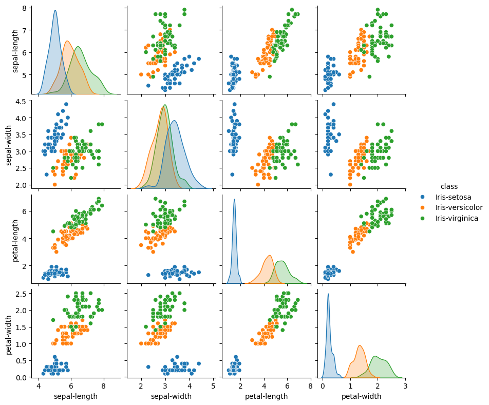

```python
sns.pairplot(df, hue="class", size=2)
```

-- Ctrl + Shift + P => JupyterL: Export to HTML,...